# Initiation à Git

2021

## Plan

- Introduction
- Mise en place
- Partie 1 : Utilisation locale
- Partie 2 : Les branches
- Partie 3 : Dépôt distant
- Améliorer sa configuration
- Conclusion
- Récapitulatif
- Liens

## Introduction

- Pourquoi versionner
- Popularité des VCS
- Présentation de Git
- Git vs GitLab/GitHub

### Pourquoi versionner

**Le Développement de code est un processus créatif**

- que nous soyons un développer créatif seul
- que nous soyons une équipe de développeurs créatifs
- que nous soyons une équipe de développeurs créatifs et efficaces

Nécessité : trouver un outil pour gagner en productivité

- qui augmente le processus de codage
- qui définit des objectifs
- qui établit un historique du travail avec des notes intégrées
- qui est capable de revenir en arrière facilement sur les différents développements
- efficace quelque soit la taille du projet
- **qui facilite le travail collaboratif**

=> **Logiciels de Versionnement de Fichiers (Version Control System ou VCS)**

### Popularité des VCS

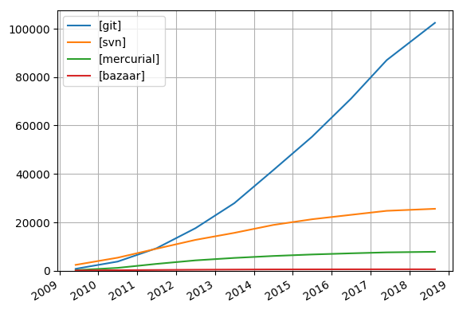

### Présentation de Git

- Problématique : Développement du noyau Linux
- Ancré sur de l'existant
  - 1er dev=1972
  - RCS=1982
  - CVS=1990
  - BitKeeper=1998
  - SVN=2000
  - Mercurial=2005
- Développement :
  - Avril 2005 : Besoin pressant d'un outil
  - La base a été codée en 15 jours par Linus Torvald
  - Juillet 2005 : projet confié à la communauté
  - Décembre 2005 : première version V1
- Caractéristiques : local + décentralisé, non linéaire, rapidité, adapté aux gros projets...
- popularité mondiale immédiate
- open-source
- multi-OS
- support local + https + ssh
- Facile à apprendre
- Système de gestion de versions le plus utilisé
- difficile à maîtriser

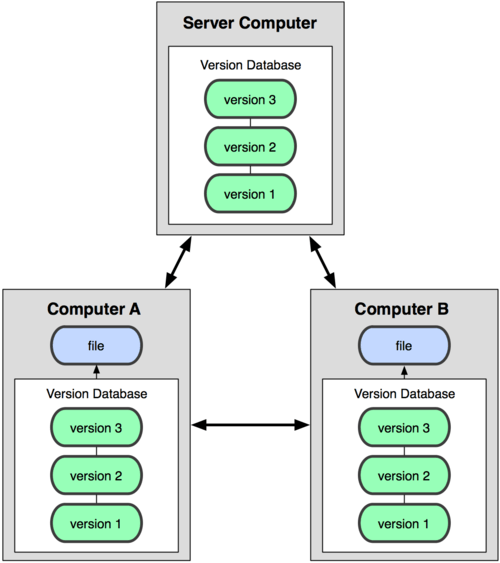

### Git différent de GitLab/GitHub

[figure not shown]

- **Git** : logiciel de versionnement de fichiers
- **GitLab/GitHub** : Forges

### Git différent de GitLab/GitHub

- plateformes de développement multi-projets (comme Redmine, TuLeap...)
- basées sur *Git* pour le versionnement de fichiers
- gestion des utilisateurs, différents accès...
- suivi de projet, demandes de fonctionnalités, suivi de bugs, boîtes à idées...
- compilations, gestion de cas tests...
- visualisation du code, historique, édition en ligne
- **GitLab est un projet libre**
- GitHub appartient à Microsoft (**attention**)

## Mise en place

- Comment Gitter ?
- Configuration
- Démarrer un dépôt Git

### Comment Gitter ?

Solution 1/3 :

- **Environnement de dev (IDE)**
  - *Forme* : Autant que d'IDE
  - *Négatif* : Occulte le process, Non scriptable
  - *Positif* : Pratique, Simplifie, Visuel

### Comment Gitter ?

Solution 2/3 :

- **Clients Graphiques (GUI)**
  - *Forme* : [Multitude](https://git-scm.com/downloads/guis)
  - *Négatif* : Occulte le process, Non scriptable, Plus lent
  - *Positif* : Pratique, Simplifie, Visuel

### Comment Gitter ?

**Solutions 3/3** :

- Ligne de commandes (CLI)
  - *Forme* : Terminal

    ```
         - Windows : git-bash, WSL
         - Linux : apt, yum, dnf...
         - MacOS : brew
    ```

  - *Négatif* : il faut aimer et savoir utiliser la CLI

    ```
           Nécessite d'avoir comporis le mécanisme
    ```

  - *Positif* : Seule façon d'utiliser toutes les possibilités

    ```
          plus rapide
          scriptable
    ```

### Comment Gitter ?

Windows, Linux, MacOSX : https://git-scm.com/download

Référence Git Pro Book : https://git-scm.com/book/fr/v2

[figure not shown]

### Comment Gitter ?

- **Notations** :
  - `<champ>` : à remplacer par une valeur
  - `[champ]` : champ optionnel
- **Ligne de commande** :
  - `git <command> --<option>=<param>`
  - `git <command> --<option> <param>`
- **Aide à l'utilisation** :
  - `git` : liste des commandes *git*
  - `git help <command>` : aide sur une commande spécifique
  - `git help config`
  - `git help commit`

### Configuration

Les fichiers de configuration :

- La configuration **système** se trouve dans `/etc/config`
- La configuration **globale** se trouve dans `~/.gitconfig`
- la configuration d'un **projet** se trouve à la racine du projet dans `.git/config`

Les champs à définir :

- `git config --global user.name "Prenom NOM"`
- `git config --global user.email "adresse_mail@exemple.fr"`
- `git config --global core.editor vi`
- `git config --global color.ui auto (activé par défaut)`
- ...

Listes des paramètres définis :

- `git config --list`

### Démarrer un dépôt Git

Initialiser un projet local

- `git init [options] <project>`

Cloner un projet en local depuis un dépôt distant

- `git clone <server> [<myproject>]`
- `git clone https://github.com/<user>/<project>`
- `git clone https://github.com/<user>/<project>`
- `git clone [ssh://]<user>@<host>[:<path>/<project>]`
- `git clone git@https://github.com:<user>/<project>`
- `git clone /tmp/<project>`

=> Création d'un répertoire `<projet>/.git`